# Principal Component Analysis (PCA) in R

[Principal component analysis](https://en.wikipedia.org/wiki/Principal_component_analysis) (PCA) is primarily used to reduce the dimensionality of a data set consisting of many variables correlated with each other, either heavily or lightly, while retaining the variation present in the dataset, up to the maximum extent

PCA is the simplest of the true eigenvector-based multivariate analyses. Often, its operation can be thought of as revealing the internal structure of the data in a way that best explains the variance in the data.

PCA is mostly used as a tool in exploratory data analysis and for making predictive models. It is often used to visualize genetic distance and relatedness between populations. The results of a PCA are usually discussed in terms of component scores, sometimes called factor scores (the transformed variable values corresponding to a particular data point), and loadings (the weight by which each standardized original variable should be multiplied to get the component score)

```r
library(dplyr)
library(caret)
head(iris)
```

|  | Sepal.Length | Sepal.Width | Petal.Length | Petal.Width | Species |
| --- | --- | --- | --- | --- | --- |
| 1 | 5.1 | 3.5 | 1.4 | 0.2 | setosa |
| 2 | 4.9 | 3.0 | 1.4 | 0.2 | setosa |
| 3 | 4.7 | 3.2 | 1.3 | 0.2 | setosa |
| 4 | 4.6 | 3.1 | 1.5 | 0.2 | setosa |
| 5 | 5.0 | 3.6 | 1.4 | 0.2 | setosa |
| 6 | 5.4 | 3.9 | 1.7 | 0.4 | setosa |

PCAmodel only works with continous variables, so we will ignore categorial variables for our model and scale all the variables before using them

```r
PCAmodel = prcomp(iris[,-5],scale=TRUE)
```

lets analyze the results of modeling

```r
summary(PCAmodel)
```

```
## Importance of components:
##                           PC1    PC2     PC3     PC4
## Standard deviation     1.7084 0.9560 0.38309 0.14393
## Proportion of Variance 0.7296 0.2285 0.03669 0.00518
## Cumulative Proportion  0.7296 0.9581 0.99482 1.00000
```

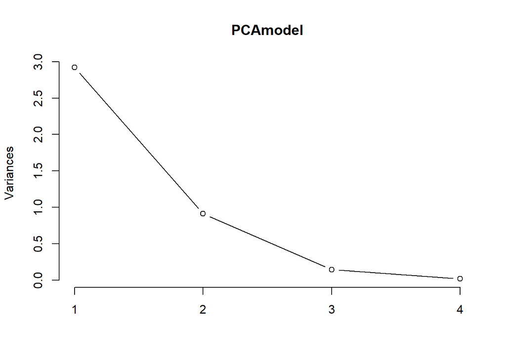

```r
plot(PCAmodel,type='l')
```

this curve is called elbow curve that shows after 3 the curve starts generating long tail and so we can ignore the remainder of components

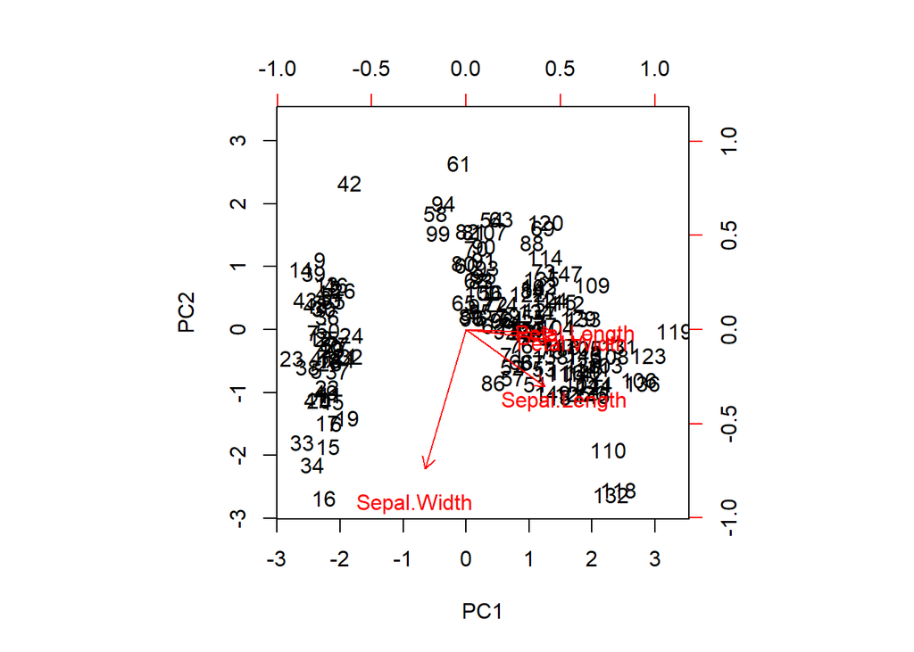

```r
biplot(PCAmodel,scale=0)
```

```r
dim(PCAmodel$x)
```

```
## [1] 150   4
```

```r
head(PCAmodel$x)
```

```
##            PC1        PC2         PC3          PC4
## [1,] -2.257141 -0.4784238  0.12727962  0.024087508
## [2,] -2.074013  0.6718827  0.23382552  0.102662845
## [3,] -2.356335  0.3407664 -0.04405390  0.028282305
## [4,] -2.291707  0.5953999 -0.09098530 -0.065735340
## [5,] -2.381863 -0.6446757 -0.01568565 -0.035802870
## [6,] -2.068701 -1.4842053 -0.02687825  0.006586116
```

we can extract the principal component for each variable.attribute from our model by using its x variable

```r
library(ggplot2)
```

```r
irisall = cbind(iris,PCAmodel$x[,1:2])
head(irisall)
```

|  | Sepal.Length | Sepal.Width | Petal.Length | Petal.Width | Species | PC1 | PC2 |
| --- | --- | --- | --- | --- | --- | --- | --- |
| 1 | 5.1 | 3.5 | 1.4 | 0.2 | setosa | -2.257141 | -0.4784238 |
| 2 | 4.9 | 3.0 | 1.4 | 0.2 | setosa | -2.074013 | 0.6718827 |
| 3 | 4.7 | 3.2 | 1.3 | 0.2 | setosa | -2.356335 | 0.3407664 |
| 4 | 4.6 | 3.1 | 1.5 | 0.2 | setosa | -2.291707 | 0.5953999 |
| 5 | 5.0 | 3.6 | 1.4 | 0.2 | setosa | -2.381863 | -0.6446757 |
| 6 | 5.4 | 3.9 | 1.7 | 0.4 | setosa | -2.068701 | -1.4842053 |

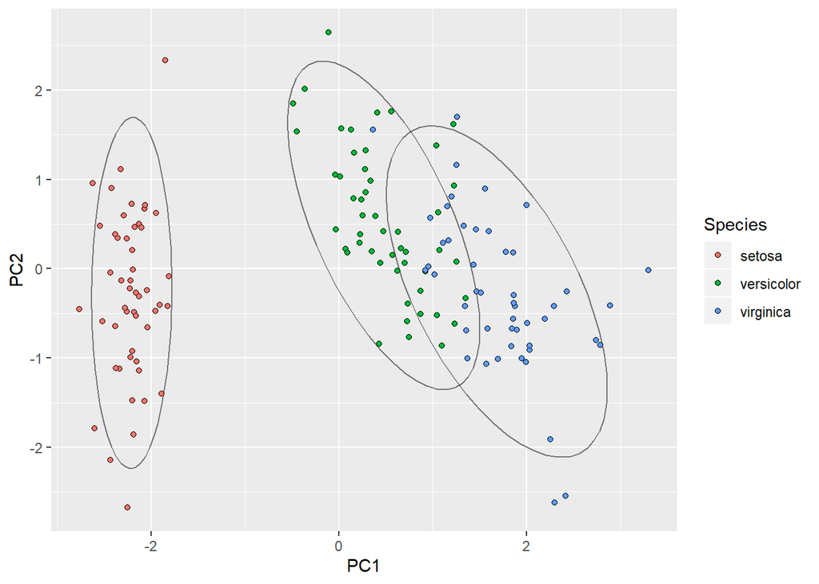

```r
ggplot(irisall,aes(PC1,PC2,col=Species,fill=Species)) +
  stat_ellipse(geon="ploygon",col="black",alpha=0.5) +
  geom_point(shape=21,col="black")
```

Lets look at the correlation betweeb principal components and variables in Iris

```r
cor(irisall[,1:4],irisall[,6:7])
```

```
##                     PC1         PC2
## Sepal.Length  0.8901688 -0.36082989
## Sepal.Width  -0.4601427 -0.88271627
## Petal.Length  0.9915552 -0.02341519
## Petal.Width   0.9649790 -0.06399985
```